# PA1_template

```r
knitr::opts_chunk$set(echo = TRUE,results = "asis")
```

## Loading and preprocessing the data

Data are loaded from the working directory and the data format is changed

```r
    setwd("F:/COURSERA/Reproducible Research/2° week")
    activity<-read.csv("activity.csv")
    activity$date<-as.Date(as.character(activity$date))
```

## What is mean total number of steps taken per day?

Total number of steps are computed. Mean and median of steps are computed. Histogram of total steps is plotted.

```r
    Total_steps<-sum(activity$steps,na.rm=T)
    mean_step<-mean(activity$steps,na.rm=T)
    median_step<-median(activity$steps,na.rm=T)
    mean_step
```

[1] 37.3826

```r
    median_step
```

[1] 0

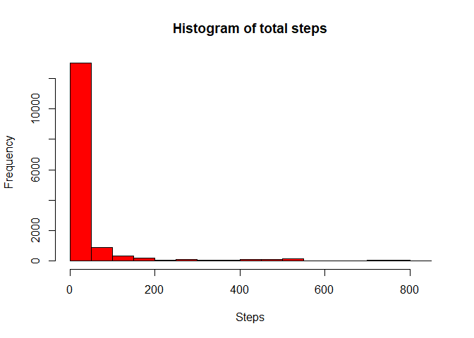

```r
    hist(activity$steps, main = "Histogram of total steps", xlab = "Steps", col =  "red")
```

## What is the average daily activity pattern?

Here is the code that groups activity dataset by interval variable and subsequently summarize the results computing the average steps for every single interval of 5 minutes time. Last, there is the 5-interval minutes with the most higher number of steps.

```r
    library(dplyr)
    media_5_int<-group_by(activity, interval)
    media_5_int_value<-summarize(media_5_int,avg_step=mean(steps,na.rm=T))
    max_5_int<-arrange(media_5_int_value,desc(avg_step))
    max_int<-max_5_int[1,1]
    max_int<-as.matrix(max_int)
    max_int
```

```
 interval
```

[1,] 835

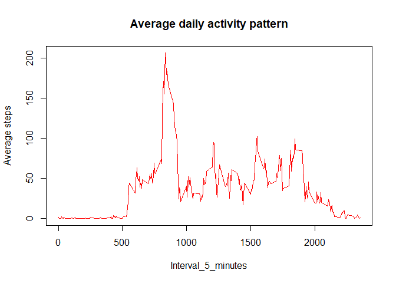

```r
    plot(media_5_int_value$interval,media_5_int_value$avg_step,type="l", main="Average daily activity pattern",xlab = "Interval_5_minutes",ylab = "Average steps",col="red",lwd=1.5)
```

## Imputing missing values

Below there is the code used to fill in missing values in the activity dateset (steps variable). Every NA’s values has been replaced by the average step relating to the corresponding interval axis. To recover the right average step needing to replace the NA values, it has been done a merge between the dataset activity and the dataset containing the average step computed for interval x-axis 5 minutes. Then, there is the value of total steps taken and the mean and median of the distribution of steps. In addition, an histogram to summarize the data.

```r
    mis_val<-sum(is.na(activity$steps))
    mis_val
```

[1] 2304

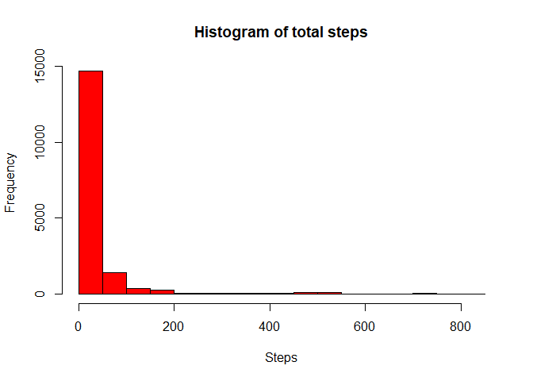

```r
    activity_no_NA<-merge(activity,media_5_int_value,by.x = "interval",by.y = "interval",all.x = T)
    activity_no_NA$steps<-as.double(activity_no_NA$steps)
    activity_no_NA<-mutate(activity_no_NA,no_NA=case_when(is.na(steps)==TRUE ~ avg_step,is.na(steps)==FALSE ~ steps))
    activity_no_NA<-select(activity_no_NA,c(interval,no_NA,date))
    hist(activity_no_NA$no_NA, main = "Histogram of total steps", xlab = "Steps", col = "red")
```

```r
    mean_step_no_NA<-mean(activity_no_NA$no_NA,na.rm=T)
    median_step_no_NA<-median(activity_no_NA$no_NA,na.rm=T)
    Total_steps_no_NA<-sum(activity_no_NA$no_NA,na.rm=T)
    mean_step_no_NA
```

[1] 37.3826

```r
    median_step_no_NA
```

[1] 0

```r
    Total_steps_no_NA
```

[1] 656737.5

## Are there differences in activity patterns between weekdays and weekends?

[figure not shown]

```r
    library(ggplot2)
    activity_no_NA$day<-weekdays(activity_no_NA$date)
    activity_no_NA<-mutate(activity_no_NA, day_type=case_when(day %in% c("lunedì","martedì","mercoledì","giovedì","venerdì") ~ "weekday",day %in% c("sabato","domenica") ~ "weekend"))
    activity_group_inter_day_type<-group_by(activity_no_NA,interval,day_type)
    activity_group_sum_inte_day_type<-summarize(activity_group_inter_day_type,avg_day_type=sum(no_NA))

    g<-ggplot(activity_group_sum_inte_day_type,aes(interval,avg_day_type))
    g+geom_line(lwd=1)+facet_grid(day_type ~ .)+labs(ylab("avg_step"))+ggtitle("Average Steps divided by type of day")
```